# Synthetic Control California Carbon Cap and Trade

Ben Gilbert

12/3/2023

## Welcome

This is an exercise to estimate the impact of California’s carbon cap and trade market on emissions per capita using synthetic control methods in R.

### Packages needed

The first thing you need to do is install and load a few packages to make sure everything runs:

```r
install.packages("devtools")
install.packages("SCtools")
install.packages("Synth")
install.packages("scul")
```

### Load packages and main dataset

```r
library(Synth)
library(tidyverse)
library(haven)
library(devtools)
if(!require(SCtools)) devtools::install_github("bcastanho/SCtools")
require(SCtools)
library(foreign)
require(scul)
require(cowplot)

setwd("C:/Users/gilbe/Dropbox/Econometrics/Petes Class/EB 590 Spring 2021/Week14")

carbon_cap <- read_dta("StateEnergyCO2PerCap.dta") %>%
   as.data.frame(.)
```

## Prepare data in format for Synth package

The Synth package requires the standard data set to be formatted in a specific way, with fields for predictors, time periods, etc.

```r
 dataprep.out <-
              dataprep(foo = carbon_cap,
                       predictors = c("income_percap" , "population" ) ,
                       predictors.op = "mean" ,
                       time.predictors.prior = 2002:2012 ,
                       special.predictors = list(
                         list("energy_co2percap" , 1990 , "mean"),
                         list("energy_co2percap" , 2000 , "mean"),
                         list("energy_co2percap" , 2012 , "mean")
                                                ),
                       dependent = "energy_co2percap",
                       unit.variable = "state",
                       unit.names.variable = "state_name",
                       time.variable = "year",
                       treatment.identifier = 6,
                       controls.identifier = c(2:5, 7:52),
                       time.optimize.ssr = 1990:2012,
                       time.plot = 1990:2018
                       )
```

# Estimate the synthetic control weights

Estimate the weights and report optimal weights and covariate balance results in tables.

```r
 synth.out <- synth(data.prep.obj = dataprep.out,
                    method = "All")
```

```
##
## X1, X0, Z1, Z0 all come directly from dataprep object.
##
##
## ****************
##  searching for synthetic control unit
##
##
## ****************
## ****************
## ****************
##
## MSPE (LOSS V): 0.1340815
##
## solution.v:
##  0.06228601 7.5025e-06 0.1747737 0.6459534 0.1169794
##
## solution.w:
##  2.075e-06 6.398e-07 8.6176e-06 8.0573e-06 1.06149e-05 1.00094e-05 1.6957e-06 0.2255662 3.4552e-06 1.5331e-06 0.1601484 0.3759672 1.02745e-05 1.4508e-06 6.4561e-06 2.7069e-06 2.6152e-06 1.6795e-06 2.2709e-06 4.0002e-06 5.5931e-06 3.9177e-06 4.7659e-06 1.26949e-05 8.6475e-06 3.2349e-06 2.57546e-05…
```

```r
###################################################
 synth.tables <- synth.tab(dataprep.res = dataprep.out,
                           synth.res = synth.out
                           )

###################################################
### Table 1: CO2 Emissions From Predictor Means Before CO2 Policy
###################################################
 synth.tables$tab.pred[1:5, ]
```

```
##                                   Treated   Synthetic Sample Mean
## income_percap                    41505.46   41517.297   37575.729
## population                    36387728.36 5472895.854 5292827.111
## special.energy_co2percap.1990       12.00      11.767      25.152
## special.energy_co2percap.2000       11.10      11.371      26.366
## special.energy_co2percap.2012        9.30       8.768      21.954
```

```r
###################################################
### Table 2: Country Weights in Synthetic California
###################################################
 synth.tables$tab.w[1:51, ]
```

```
##    w.weights           unit.names unit.numbers
## 2      0.000              Alabama            2
## 3      0.000               Alaska            3
## 4      0.000              Arizona            4
## 5      0.000             Arkansas            5
## 7      0.000             Colorado            7
## 8      0.000          Connecticut            8
## 9      0.000             Delaware            9
## 10     0.226 District of Columbia           10
## 11     0.000              Florida           11
## 12     0.000              Georgia           12
## 13     0.160               Hawaii           13
## 14     0.376                Idaho           14
## 15     0.000             Illinois           15
## 16     0.000              Indiana           16
```

[output cut: 37 more lines]

## Show the main takeaway figures

These are the main results before evaluating and testing.

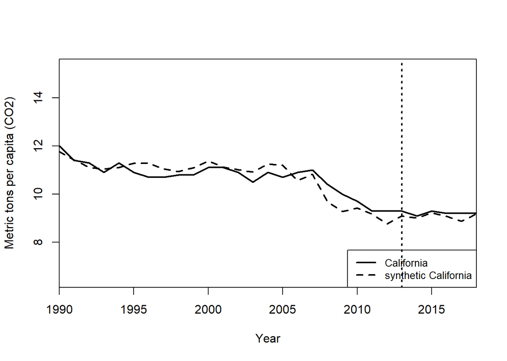

```r
###################################################
### Figure 4: Path Plot of per capita CO2 Emissions
###################################################
  path.plot(synth.res = synth.out,
           dataprep.res = dataprep.out,
           Ylab = "Metric tons per capita (CO2)",
           Xlab = "Year",
          # Ylim = c(0,3),
           Legend = c("California","synthetic California"),
           Legend.position = "bottomright"
           )
# Add line
abline(v=2013,lty="dotted",lwd=2)
arrows(2010,1.0,2012,1.0,col="black",length=.1)
Cex.set <- 1
text(2004,1.0,"Cap and Trade",cex=Cex.set)
```

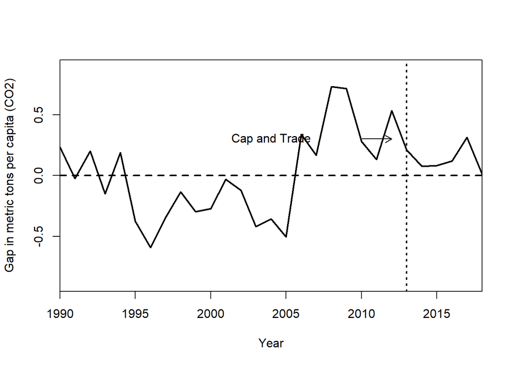

```r
###################################################
### Figure 5: Gap in per capita CO2 Emissions between CA and Synthetic CA
###################################################
 gaps.plot(synth.res = synth.out,
           dataprep.res = dataprep.out,
           Ylab = "Gap in metric tons per capita (CO2)",
           Xlab = "Year",
           #Ylim = c(-0.5,0.5),
           Main = NA
           )

#Add line
abline(v=2013,lty="dotted",lwd=2)
arrows(2010,0.3,2012,0.3,col="black",length=.1)
Cex.set <- 1
text(2004,0.3,"Cap and Trade",cex=Cex.set)
```

## Check placebo treatment years: 2008 and 2003

```r
###################################################
### Figure 6:  Placebo in-time tests 2008/2003
###################################################
#Placebo test in time for 2008
 dataprep.out <-
              dataprep(foo = carbon_cap,
                       predictors = c("income_percap" , "population" ) ,
                       predictors.op = "mean" ,
                       time.predictors.prior = 1998:2007 ,
                       special.predictors = list(
                         list("energy_co2percap" , 1990 , "mean"),
                         list("energy_co2percap" , 2000 , "mean"),
                         list("energy_co2percap" , 2007 , "mean")
                                                ),
                       dependent = "energy_co2percap",
                       unit.variable = "state",
                       unit.names.variable = "state_name",
                       time.variable = "year",
                       treatment.identifier = 6,
                       controls.identifier = c(2:5, 7:52),
                       time.optimize.ssr = 1990:2007,
                       time.plot = 1990:2012
                       )

synth.out <- synth(
                   data.prep.obj = dataprep.out,
                   method = "BFGS"
                   )
```

```
##
## X1, X0, Z1, Z0 all come directly from dataprep object.
##
##
## ****************
##  searching for synthetic control unit
##
##
## ****************
## ****************
## ****************
##
## MSPE (LOSS V): 0.07552795
##
## solution.v:
##  0.002375318 4.6969e-06 0.1236938 0.6842812 0.1896449
##
## solution.w:
##  6.7435e-06 2.1393e-06 2.50886e-05 1.02724e-05 1.50772e-05 1.99899e-05 1.36427e-05 0.369271 3.32359e-05 1.46442e-05 0.2440297 0.3815217 1.58426e-05 5.279e-06 8.647e-06 8.5613e-06 6.0979e-06 3.8026e-06 1.46767e-05 2.19422e-05 3.19852e-05 1.52998e-05 1.27105e-05 1.41145e-05 1.20252e-05 7.3671e-06 9…
```

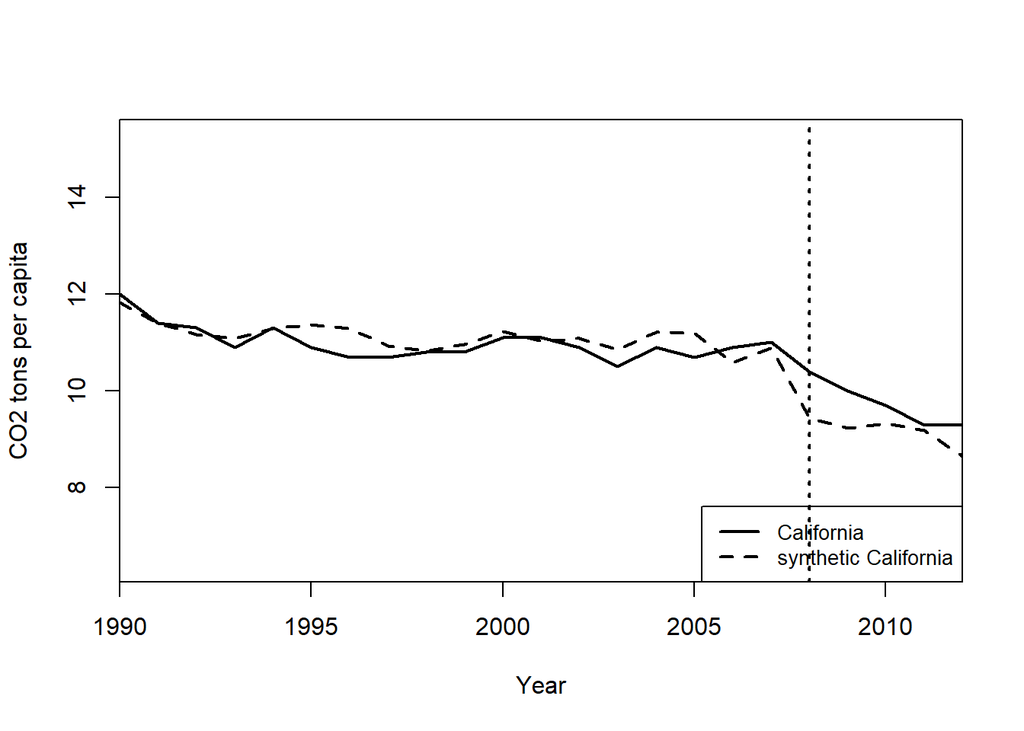

```r
 path.plot(synth.res = synth.out,
           dataprep.res = dataprep.out,
           Ylab = "CO2 tons per capita",
           Xlab = "Year",
           #Ylim = c(0,3),
           Legend = c("California","synthetic California"),
           Legend.position = "bottomright"
           )

# Add line
abline(v=2008,lty="dotted",lwd=2)
arrows(2005,1.0,2007,1.0,col="black",length=.1)
Cex.set <- 1
text(2002,1.0,"Placebo Policy",cex=Cex.set)
```

```r
#Placebo test in time for 2003
 dataprep.out <-
              dataprep(foo = carbon_cap,
                       predictors = c("income_percap" , "population" ) ,
                       predictors.op = "mean" ,
                       time.predictors.prior = 1993:2002 ,
                       special.predictors = list(
                         list("energy_co2percap" , 1990 , "mean"),
                         list("energy_co2percap" , 2000 , "mean"),
                         list("energy_co2percap" , 2002 , "mean")
                                                ),
                       dependent = "energy_co2percap",
                       unit.variable = "state",
                       unit.names.variable = "state_name",
                       time.variable = "year",
                       treatment.identifier = 6,
                       controls.identifier = c(2:5, 7:52),
                       time.optimize.ssr = 1990:2002,
                       time.plot = 1990:2012
                       )

synth.out <- synth(
                   data.prep.obj = dataprep.out,
                   method = "All"
                   )
```

```
##
## X1, X0, Z1, Z0 all come directly from dataprep object.
##
##
## ****************
##  searching for synthetic control unit
##
##
## ****************
## ****************
## ****************
##
## MSPE (LOSS V): 0.03543382
##
## solution.v:
##  5.07219e-05 1.3808e-06 0.2935603 0.5568197 0.1495679
##
## solution.w:
##  6.03709e-05 1.90772e-05 0.0002419888 9.5895e-05 0.000133011 0.0001041873 3.3042e-06 0.253242 0.0002707898 0.000110764 0.181842 0.1036347 0.0001171874 4.60322e-05 7.45984e-05 7.68979e-05 5.64446e-05 3.08218e-05 0.000172063 0.0001709751 0.0002473616 0.0001290979 0.0001094749 0.0001306543 0.0001084…
```

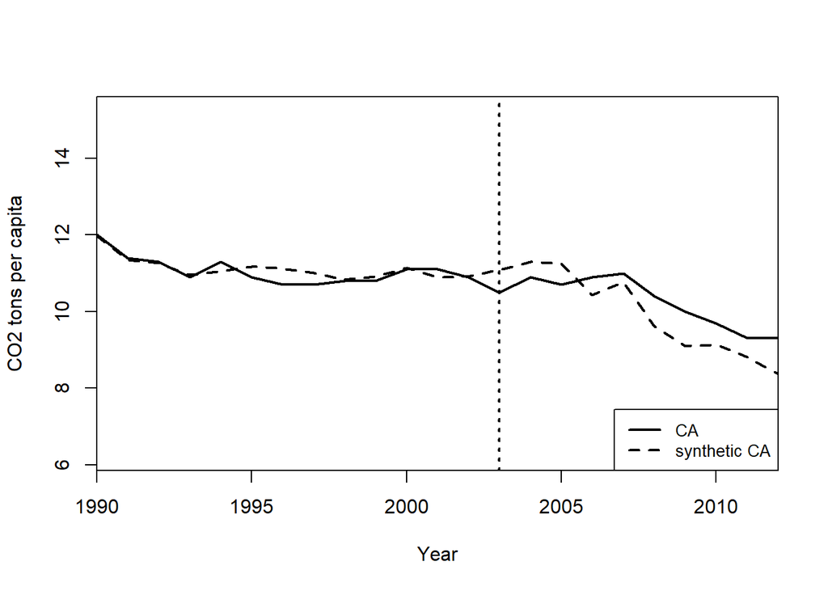

```r
 path.plot(synth.res = synth.out,
           dataprep.res = dataprep.out,
           Ylab = "CO2 tons per capita",
           Xlab = "Year",
           #Ylim = c(0,3),
           Legend = c("CA","synthetic CA"),
           Legend.position = "bottomright"
           )

# Add line
abline(v=2003,lty="dotted",lwd=2)
arrows(2000,2.0,2002,2.0,col="black",length=.1)
Cex.set <- 1
text(1998,2.0,"Placebo Policy",cex=Cex.set)
```

## Check placebo states and calculate MSPE

Placebos using SCtools package:

```r
###################################################
### Placebo in-space tests
###################################################

# Restore original data prep object (so treat year is 2013, not 2003 as above)
# and original synth results (should have just named them differently above)
 dataprep.out <-
              dataprep(foo = carbon_cap,
                       predictors = c("income_percap" , "population" ) ,
                       predictors.op = "mean" ,
                       time.predictors.prior = 2002:2012 ,
                       special.predictors = list(
                         list("energy_co2percap" , 1990 , "mean"),
                         list("energy_co2percap" , 2000 , "mean"),
                         list("energy_co2percap" , 2012 , "mean")
                                                ),
                       dependent = "energy_co2percap",
                       unit.variable = "state",
                       unit.names.variable = "state_name",
                       time.variable = "year",
                       treatment.identifier = 6,
                       controls.identifier = c(2:5, 7:52),
                       time.optimize.ssr = 1990:2012,
                       time.plot = 1990:2018
                       )

 synth.out <- synth(data.prep.obj = dataprep.out,
                    method = "All")

# Using devtools and SCtools:
placebos <- generate.placebos(dataprep.out, synth.out)
```

Plotting:

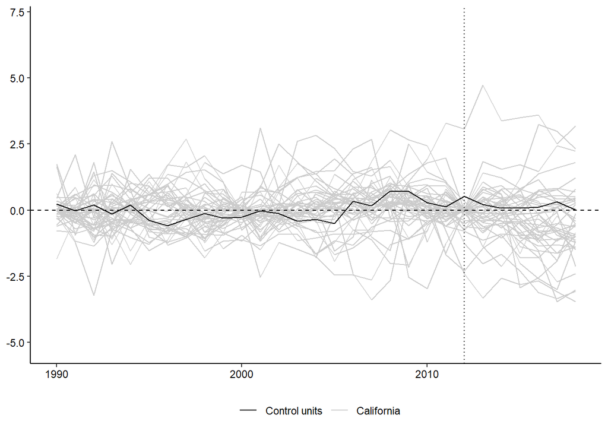

```r
plot_placebos(placebos, discard.extreme = TRUE, mspe.limit = 20)
```

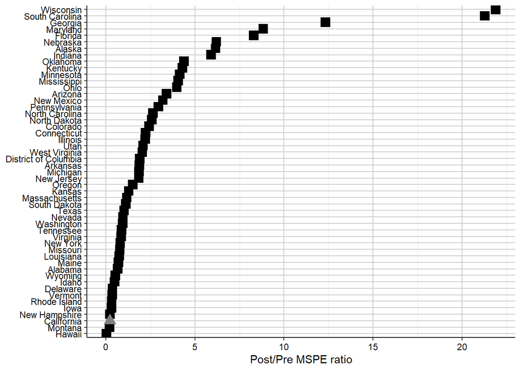

```r
mspe.plot(placebos)
```

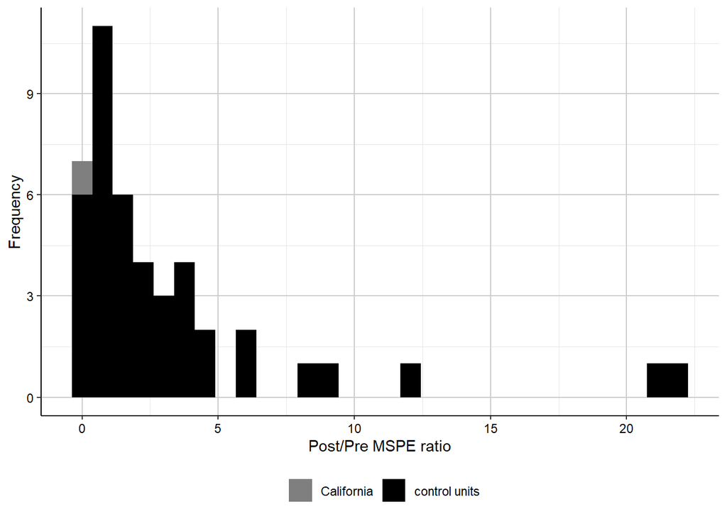

```r
mspe.plot(placebos, discard.extreme = TRUE, mspe.limit = 20, plot.hist = TRUE)
```

# Check using SCUL

This is not an apples to apples comparison - SCUL does not apply the LASSO penalty to the Synth objective function. It uses the full pre-treatment time series of donor outcomes and predictors (instead of potential summary statistics and other linear combinations of those predictors, as in Synth).

Possible predictors: donor units’ time series of income per capity and population, as well as donor units’ pretreatment outcome of CO2 emissions from energy.

Prepare data:

```r
# remove redundant country index and unused predictors
datasetup <- carbon_cap %>% select(-c("state_name"))
# column order by country
datasetup <- pivot_wider(datasetup, names_vary="slowest", names_from = "state", values_from = c("energy_co2percap", "income_percap" , "population"))

# for full donor pool use all time series from all donor countries (not Sweden country 13)
XData <- datasetup %>% select(-c("year", "energy_co2percap_6", "income_percap_6", "population_6"))

# for limited donor pool, just use pre-treatment donor outcomes
Ydonors <- unlist(dataprep.out$Y0plot)
Ydonors <- as.data.frame(unlist(Ydonors))

# outcome series
YData <- unlist(dataprep.out$Y1plot)
YData <- as.data.frame(unlist(YData))

# time index
year <- carbon_cap %>% select("year") %>% distinct(year)
YData <- cbind(year, YData)
colnames(YData) <- c("year", "energy_co2percap")
```

Process data for use by SCUL package. Here I’m using all the possible donor time series, but could replace “XData” with “Ydonors” if only wanted pre-treatment outcomes from the donor pool:

```r
# Preprocess() checks for non-numeric, missing, or constant variables
# drops any column that has any of these issues
processed.YData <- Preprocess(YData)

# cross validation will be run on many subsets. Need to make sure each subset
# also has variation using PreprocessSubset().
# Identical to Preprocess() but runs on each CV subset
TreatmentBeginsAt <- 24 # Here the 24th row is 2013, the year of the treatment
PostPeriodLength <- nrow(processed.YData) - TreatmentBeginsAt + 1
PrePeriodLength <- TreatmentBeginsAt-1
# Ideally equal to post-treatment, but shorter if not many pre-treatment time periods
#NumberInitialTimePeriods <- 10
NumberInitialTimePeriods <- 5
processed.YData <- PreprocessSubset(processed.YData,
                                       TreatmentBeginsAt ,
                                       NumberInitialTimePeriods,
                                       PostPeriodLength,
                                       PrePeriodLength)
head(processed.YData)
```

```
##      year energy_co2percap
## 1990 1990             12.0
## 1991 1991             11.4
## 1992 1992             11.3
## 1993 1993             10.9
## 1994 1994             11.3
## 1995 1995             10.9
```

```r
# create list (SCUL.input) for later SCUL commands to call
# applies PreprocessSubset() and Preprocess() to all data
# want all entries (time, y, x.DonorPool, x.PlaceboPool) to be data.frames
# Cohen's D is a unit-free measure of fit between Y.actual and Y.scul
# It's the standardized mean difference between Y.actual and Y.scul in pretreatment period
# measured in standard deviation terms. Max of 0.25 std. devs is a rule of thumb.
SCUL.input <- OrganizeDataAndSetup (
  time =  YData %>% select(year),
  y = YData %>% select(energy_co2percap),
  TreatmentBeginsAt = TreatmentBeginsAt,
  x.DonorPool = XData,
  CohensDThreshold = 0.25,
  NumberInitialTimePeriods = NumberInitialTimePeriods,
  TrainingPostPeriodLength = 5,
  x.PlaceboPool = XData,
  OutputFilePath="C:/Users/gilbe/Dropbox/"
)
```

Fit the model and plot some diagnostics:

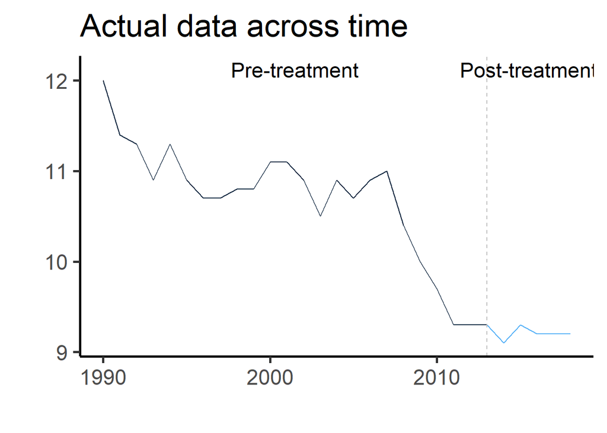

```r
# Estimation by LASSO with rolling CV
SCUL.output <- SCUL(plotCV = TRUE)
GraphTargetData()
```

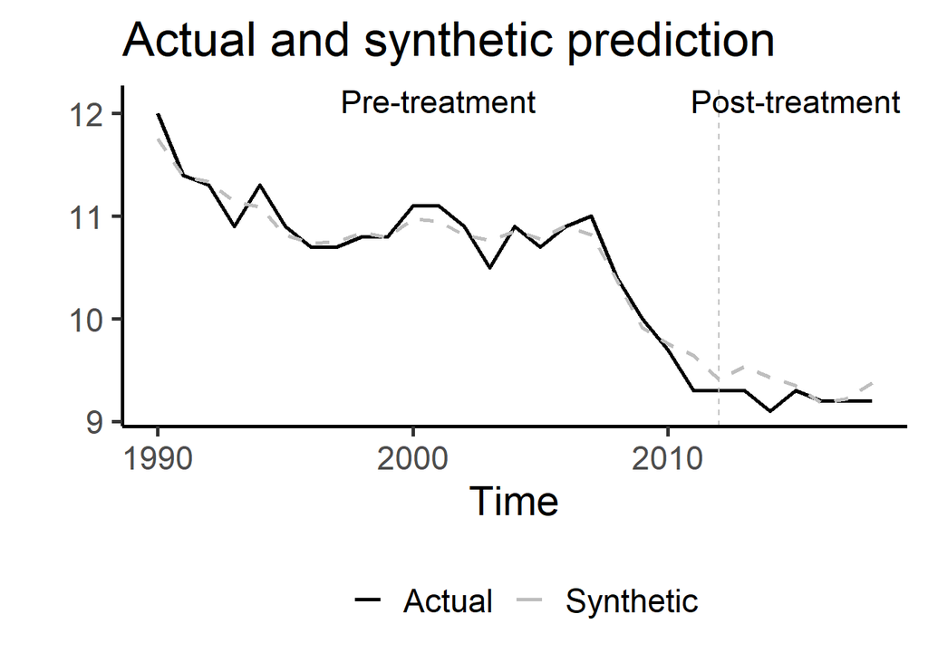

```r
PlotActualvSCUL()
```

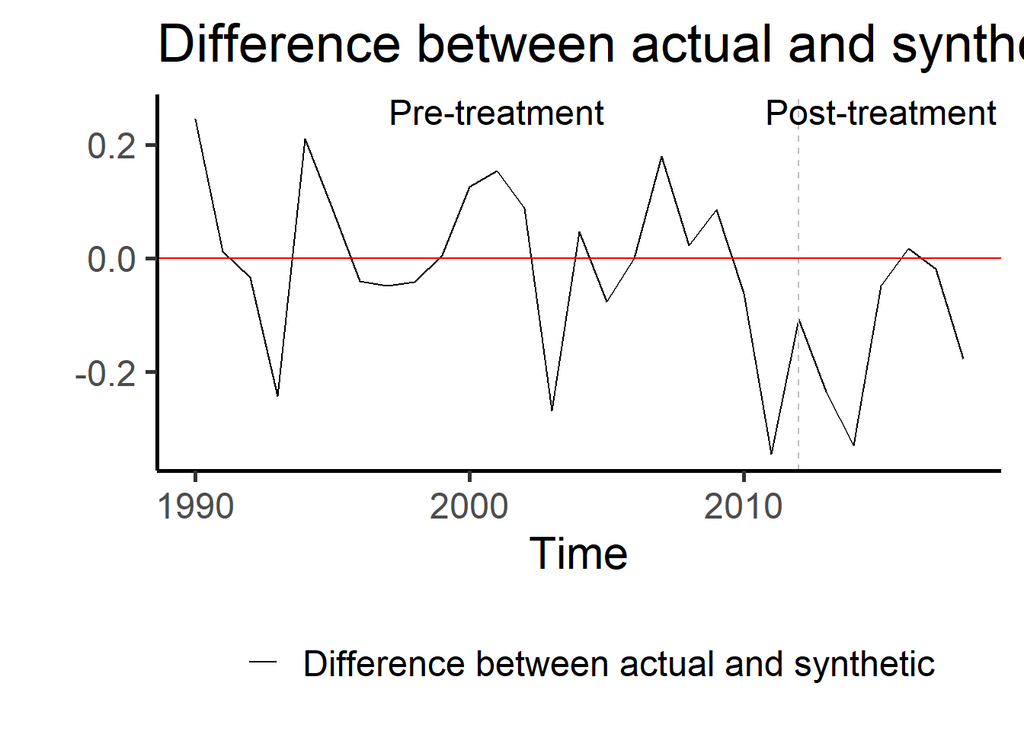

```r
PlotDiffOfActualvSCUL()
```

```r
PlotShareTable()
```

|  | Share for First Prediction | Share for Most Recent Prediction | Coefficient |
| --- | --- | --- | --- |
| Intercept | 0.51 | 0.52 | 24.22 |
| population_50 | 0.32 | 0.32 | 0.00 |
| population_20 | 0.08 | 0.08 | 0.00 |
| energy_co2percap_46 | 0.04 | 0.03 | 0.08 |
| energy_co2percap_4 | 0.02 | 0.02 | 0.08 |
| energy_co2percap_13 | 0.01 | 0.01 | 0.05 |
| energy_co2percap_7 | 0.01 | 0.01 | 0.02 |
| energy_co2percap_33 | 0.00 | 0.00 | 0.01 |
| energy_co2percap_12 | 0.00 | 0.00 | 0.01 |
| energy_co2percap_49 | 0.00 | 0.00 | 0.00 |

Now do some inference on how well the model performs:

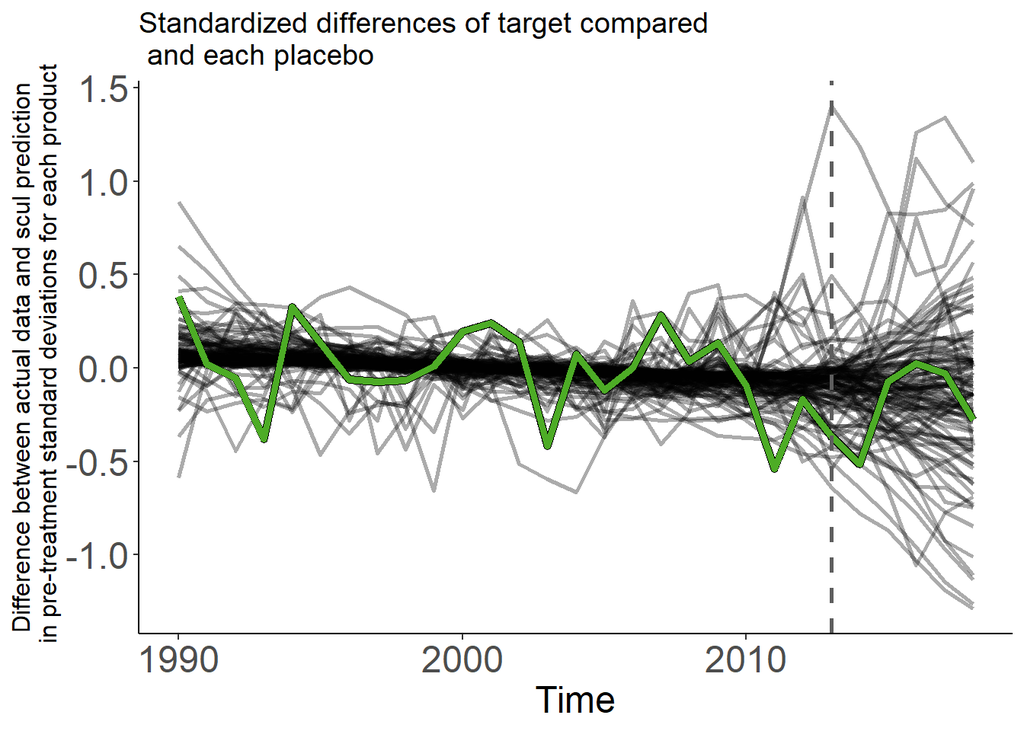

```r
# Really should restrict each placebo not to have it's (endogenous) variables in the donor pool
drop_vars_from_same_FIPS <-
  "select(-ends_with(substring(names(x.PlaceboPool)[h],nchar(names(x.PlaceboPool)[h]) - 2 + 1, nchar(names(x.PlaceboPool)[h]))))"

SCUL.inference <- CreatePlaceboDistribution(
  DonorPoolRestrictionForEachPlacebo = drop_vars_from_same_FIPS
)

smoke_plot <- SmokePlot()
smoke_plot
```

Compare null distribution of placebo effects to actual effect:

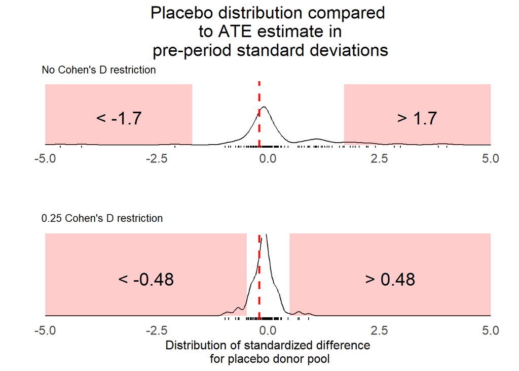

```r
# Grab standardized differences from saved objects
Results.y.StandardizedDiff <- unlist(smoke_plot$layers[[2]]$data$std_diff)
Results.y.StandardizedDiff <- as.data.frame(unlist(Results.y.StandardizedDiff))

# Show distribution of standardized differences (treatment effects) in placebo pool
# vs estimated difference
# with and without a Cohen's D restriction on pre-period fit in placebo pool
# Rejection region is 10% of distribution
# narrower null distribution around zero is better

# Plot null distribution with no restriction on pre-period fit
NullDist.Full <- PlotNullDistribution(
  CohensD = 999,
  StartTime = TreatmentBeginsAt,
  EndTime = length(SCUL.output$y.actual),
  height = 2,
  AdjustmentParm = 1,
  BandwidthParm = .25,
  title_label = "Placebo distribution compared\n to ATE estimate in\n pre-period standard deviations",
  y_label  = " ",
  x_label  =  "",
  subtitle_label  =  "No Cohen's D restriction",
  rejection_label  =  ""
) +
  geom_vline(
    xintercept = mean(Results.y.StandardizedDiff[TreatmentBeginsAt:nrow(Results.y.StandardizedDiff),]),
    linetype = "dashed",
    size = 1,
    color = "red")
# Plot null distribution 0.25 cohen's D restriction on pre-period fit
NullDist.25 <- PlotNullDistribution(
  CohensD = 0.25,
  StartTime = TreatmentBeginsAt,
  EndTime = length(SCUL.output$y.actual),
  height = 2,
  AdjustmentParm = 1,
  BandwidthParm = .25,
  y_label  = "",
  x_label  =  "Distribution of standardized difference\n for placebo donor pool",
  subtitle_label  =  "0.25 Cohen's D restriction",
  rejection_label  =  "",
  title_label = " ",

) +
  geom_vline(
    xintercept = mean(Results.y.StandardizedDiff[TreatmentBeginsAt:nrow(Results.y.StandardizedDiff),]),
    linetype = "dashed",
    size = 1,
    color = "red")

# Plot n
# Combine the three plots
combined_plot <- plot_grid(
  NullDist.Full,NullDist.25,
  ncol = 1)

# Display the plot
combined_plot
```

Calculate p-values for treatment significance:

```r
# Permutation-based p-values of treatment significance:
PValue(
  CohensD = 999,
  StartTime = SCUL.input$TreatmentBeginsAt,
  EndTime = nrow(Results.y.StandardizedDiff)
)
```

```
##   p.value.high
## 1         0.55
```

```r
PValue(
  CohensD = .25,
  StartTime = SCUL.input$TreatmentBeginsAt,
  EndTime = nrow(Results.y.StandardizedDiff)
)
```

[output not shown]